# Using a Stochastic Block Model to quantify differences in connectivity ipsi-laterally vs contra-laterally

Eric Bridgeford

September 29, 2017

# Setting

## Task

Given:

- $n$ samples of graphs, $\left\{(g_i)\right\}_{i=1}^n$.
- A graph, $g_i \in G$, where $g_i = (E, V, w)$ for $N=|V|$ regions of interest and $w(v_i, v_j) = w_{ij}$.
- a partitioning of the vertices into $C_1$, the left hemisphere ROIs, and $C_2$, the right hemisphere ROIs, where $C_1 \cup C_2 = V$.

Determine if there exists a difference in the connectivity among the vertices in $C_1$ and $C_2$ within a particular modality, and between the communities $C_1$ and $C_2$, for the functional and diffusion connectomes.

## Statistical Model

Assume we have a random variable $A$ which can be characterized by the Stochastic Block Model with parameters $G$, $B$:

$$\begin{align*}
A \sim SBM(G, B)
\end{align*}$$

where $G$ is a grouping of the $N$ vertices in our graph into our respective communities and $B$ represents the parameters for within and between group edge probabilities. Assuming the number of edges in our graph are binomially distributed wrt the parameter $p$, we can estimate the number of edges for each group:

$$\begin{align*}
f_B(n, k | p) &= \begin{pmatrix}n \\ k\end{pmatrix}p^k (1 - p)^{n - k} \\
\mu_{\hat{k}} &= np \\
\sigma^2_{\hat{k}} &= np(1 - p)
\end{align*}$$

Assuming that $p = \frac{k}{n}$, then we can see that:

$$\begin{align*}
\mu_{\hat{p}} &= \frac{k}{n} \\
\sigma^2_{\hat{p}} &= \frac{np(1-p)}{n^2} = \frac{p(1-p)}{n}
\end{align*}$$

where $p$ is the probability of a given edge, $k$ are the number of connected edges, and $n$ is the number of possible edges. We can therefore define an estimator of $B$, $\hat{B}$ where connections betweeb community $C_l$ and $C_m$ can be modelled iid:

$$\begin{align*}
\hat{B}_{lm} &= \mathcal{N}(\mu_{lm}, \sigma_{lm})
\end{align*}$$

where $\hat{\mu}_{lm} = \frac{1}{\left|C_l \times C_m\right|}sum_{(i, j) \in E(C_l \times C_m)} A_{ij}$, and $\hat{\sigma}^2_{lm} = \frac{\hat{\mu}_{lm}(1 - \hat{\mu}_{lm})}{\left|C_l \times C_m\right|}$.

Grouping our vertices into the left and right hemispheres, under the above model we end up with:

$$\begin{align*}
\hat{B} &\sim \mathcal{N}\left(\mu_B, \Sigma_B\right) \\
\hat{\mu}_B &= \begin{bmatrix}
p_{ll} \\ p_{rl} \\
p_{lr} \\ p_{rr}
\end{bmatrix} \\
\hat{\Sigma}_B &= \begin{bmatrix}
\frac{p_{ll}(1 - p_{ll})}{\left(\frac{N}{2}\right)^2} & 0 & 0 & 0 \\
0 & \frac{p_{rl}(1 - p_{rl})}{\left(\frac{N}{2}\right)^2} & 0 & 0 \\
0 & 0 & \frac{p_{lr}(1 - p_{lr})}{\left(\frac{N}{2}\right)^2} & 0 \\
0 & 0 & 0 & \frac{p_{rr}(1 - p_{rr})}{\left(\frac{N}{2}\right)^2} \\
\end{bmatrix}
\end{align*}$$

Regrouping to only consider the ipsi-lateral vs. contra-lateral edges, we can simplify:

$$\begin{align*}
\hat{\mu}_B &= \begin{bmatrix}
p_{i} \\
p_{c}
\end{bmatrix} \\
\hat{\Sigma}_B &= \begin{bmatrix}
\frac{p_{i}(1 - p_{i})}{\left(\frac{N}{2}\right)^2} & 0 \\
0 & \frac{p_{c}(1 - p_{c})}{\left(\frac{N}{2}\right)^2}
\end{bmatrix}
\end{align*}$$

where $p_i$ represents the probability of a ipsi-lateral connection, and $p_c$ the probability of a contra-lateral connection. Then given the connectome megamean as an adjacency matrix $M \in \left\{0, 1\right\}^{N \times N}$ with $N$ vertices, we can compute $p_i$ and $p_c$ as follows:

$$\begin{align*}
I &= \left\{(i, j): \textrm{vertex $i$ and vertex $j$ are in the same hemisphere}\right\} \\
C &= \left\{(i, j): \textrm{vertex $i$ and vertex $j$ are not in the same hemisphere}\right\} \\
p_i &= \frac{1}{|I|} \sum_{(i, j) \in I} M_{ij} \\
p_c &= \frac{1}{|C|} \sum_{(i, j) \in C} M_{ij}
\end{align*}$$

## Statistical Goal

With $H_0: p_I <= p_C$, $H_A: p_I > p_C$, determine:

$$\begin{align*}
\mathbb{P}(\textrm{reject $H_0$ in favor of $H_A$ | $H_0$ is true})
\end{align*}$$

## Test Statistic

1. Population $\hat{p}$: [Paired Welch’s T-Test](https://en.wikipedia.org/wiki/Welch%27s_t-test) for testing whether two populations have equal means given they have different variances in the univariate case, and obsevations in one class can be paired to observations in the other class.

$$\begin{align*}
T = \frac{\bar{\delta}}{\sqrt{\frac{s_1^2}{n_1} + \frac{s_2^2}{n_2}}}
\end{align*}$$

where $\bar{\delta} = \mathbb{E}\left[X_1 - X_2\right]$.

2. Mean $\hat{p}$: [Welch’s T-Test](https://en.wikipedia.org/wiki/Welch%27s_t-test) for testing whether populations have equal means given that they have different variances in the univariate case.

$$\begin{align*}
T = \frac{\bar{X}_1 - \bar{X}_2}{\sqrt{\frac{s_1^2}{n_1} + \frac{s_2^2}{n_2}}}
\end{align*}$$

Since our random variables are all assumed to be independent (covariance terms are all zero), we can assume that $s_1 = \Sigma_{11}$, and $s_2 = \Sigma_{22}$.

and the degrees of freedom can be calculated as follows:

$$\begin{align*}
\nu &= \frac{\left(\frac{s_I^2}{n_1} + \frac{s_C^2}{n_2}\right)^2}{\frac{s_1^4}{n_1^2 \nu_1} + \frac{s_2^4}{n_2^2\nu_2}}
\end{align*}$$

where the standard deviation $s_j = \sqrt{\frac{p_j(1 - p_j)}{\left(\frac{N}{2}\right)^2}}$

where $\nu_1 = n_1 - 1, \; \nu_2 = n_2 - 1$.

We can then use a one-sided test given $T, \nu$ to get a $p-$ value.

## P-Value

We can compute a p-value of falsely rejecting the null hypothesis by simply finding the area:

$$\begin{align*}
p = \int_{-T_{observed}}^{\infty}p(x, df) dx = 1 - \int_{-\infty}^{T_{observed}} p(x, df) dx
\end{align*}$$

where $p(x, df)$ is the pdf for the $T$ distribution with degrees of freedom $df$.

## Statistical Power

The statistical power can be computed as the inverse of the probability of making a Type II ($\beta$) error. A type II error can be defined as follows:

$$\begin{align*}
\beta = \mathbb{P}(\textrm{reject $H_A$ in favor of $H_0$ | $H_A$ is true}) = \mathbb{P}(T_{observed} > T_{critical})
\end{align*}$$

where $T_{critical}$ is the test-statistic at the given level of significance $\alpha$ specified by our test. To compute the power, we will compute the rejection cutoff for the test-statistic, and then simulate data under the alternative hypothesis, and see how many times we would reject the null hypothesis in our simulated data. In pseudo-code:

```r
Compute_Power(n, means, sds, sig=.95):
  cutoff = T_{dist}(sig, df=n-2)
  tstat = []
  for i in 1:n
    snull = random_normal(n, means[1], sds[1])
    salt = random_normal(n, means[2], sds[2])
    tstat[i] = welch_ttest(snull, salt)$statistic
  end
  return(sum(ts > cutoff)/n)
```

# Simulations

## Simulated Data

### Consistency of Estimators for $\hat{p}$

Here, we will verify that our estimators of $\hat{p}$ are correct, that is, that we can accurately estimate $\mu_{\hat{p}}$ and $\sigma^2_{\hat{p}}$ given binomially distributed edges:

```r
# package dependencies -------------------
require(ggplot2)
library(latex2exp)
require(igraph)
require(fmriutils)
# Util functions ------------------------
# variance under the given model with params probability p, and number of edges n
model.var = function(p, n) {
  p*(1 - p)/n
}

# compute the mu and sigma params associated with an input array under the model
model.params = function(dat) {
  mu = sum(dat)/length(dat)
  var = model.var(mu)
  return(list(mu = mu, sigma = sqrt(var)))
}

# accepts a [n x n] adjacency matrix and computes the probabilities associated with an SBM
# where the vertices are grouped such that union_i(groups) = V(A) and
# intersection(group_i, group_j) = NULL for all i != j
block_data = function(matrix, groups) {
  # matrix is adwi_thresh n x n array
  # groups is a grouping of the vertices in the matrix as a list
  blocks = array(NaN, dim=c(2,2))
  for (i in 1:length(groups)) {
    for (j in 1:length(groups)) {
      blocks[i, j] = mean(matrix[groups[[i]], groups[[j]]])
    }
  }
  return(blocks)
}

# computes the analytical welch t-test given mu and the number of observations
# and the number of samples. Optionally accepts params for the degrees of freedom
# to override the default computation.
ana.welch_ttest = function(u1, u2, ne1, ne2, ns1=NaN, ns2=NaN, df=NaN, verbose=TRUE) {
  s1 = sqrt(model.var(p=u1, n=ne1))
  s2 = sqrt(model.var(p=u2, n=ne2))
  tstat = (u1 - u2)/sqrt(s1^2/ns1 + s2^2/ns2)
  if (!is.nan(df)) {
    df = df
  } else {
    dfnum = (s1^2/ns1 + s2^2/ns2)^2
    dfdenom = s1^4/(ns1^2*(ns1 - 1)) + s2^4/(ns2^2*(ns2-1))
    df = round(dfnum/dfdenom)
  }
  p = 1 - pt(tstat, df=df)
  return(list(t=tstat, p=p, df=df))
}

# computes the power of the model under a given significance level
# accepts params for a number of simulations to average power over, and a
# number of graphs for each computation
# number of edges defines the number of edges to use in the binomial simulation
t.power = function(means, ne=1225, sig=.95, nsim=100, ngr=100) {
  ucut = qt(sig, df=ngr)  # t-statistic of null at the given significance level with ne-2 degrees of freedom
  ts = replicate(nsim, {  # replicate our described test n tsim times
    alt = replicate(ngr, sum(rbinom(n = ne, size=1, prob = means[1]))/ne)
    null = replicate(ngr, sum(rbinom(n = ne, size=1, prob = means[2]))/ne)
    t.test(alt, null, alternative = "greater", var.equal = FALSE)$statistic
  })
  ana_tstat = ana.welch_ttest(means[1], means[2], ne, ne, ngr, ngr)$t
  return(list(power=sum(ts > ucut)/nsim, diff=abs(mean(ts) - ana_tstat)/ana_tstat))
}

# accepts a matrix and thresholds/binarizes it
thresh_matrix = function(matrix, thresh=0.5) {
  thr = quantile(matrix, thresh)
  return(ifelse(matrix > thr, 1, 0))
}
```

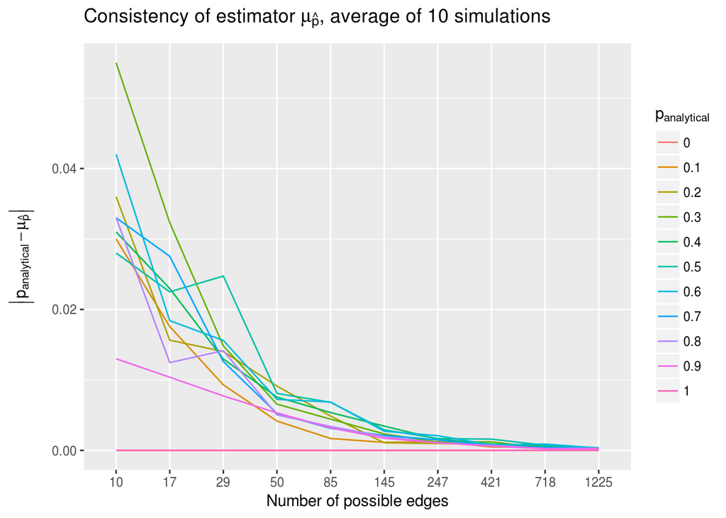

```r
ns = round(10^seq(1, log10(1225), length=10))
ps = seq(0, 1, length=11)
ndat = length(ns)*length(ps)
empty_ar = array(NaN, dim=c(ndat))
results = data.frame(n = empty_ar, p = empty_ar, mu = empty_ar, var = empty_ar)
counter = 1
nsim = 10
for (n in ns) {
  for (p in ps) {
    v_ar = array(NaN, dim=c(nsim))
    m_ar = array(NaN, dim=c(nsim))
    for (i in 1:nsim) {
      pemp = replicate(n, {
        dat = rbinom(n = n, p = p, size=1)
        phat = sum(dat)/length(dat)
        })
      m_ar[i] = abs(mean(pemp) - p)
      v_ar[i] = abs(var(pemp) - model.var(p, n))
    }
    results[counter,] = data.frame(n = n, p = p, mu = mean(m_ar),
                                   var = mean(v_ar))
    counter <- counter + 1
  }
}

results$n = factor(results$n)
results$p = factor(results$p)

ggplot(results, aes(x = n, y = mu, group=p, color=p)) +
  geom_line() +
  ggtitle(TeX('Consistency of estimator $\\mu_{\\hat{p}}$, average of 10 simulations')) +
  xlab("Number of possible edges") +
  ylab(TeX('$\\left|p_{analytical} - \\mu_{\\hat{p}}\\right|$')) +
  scale_color_discrete(name=TeX("$p_{analytical}$"))
```

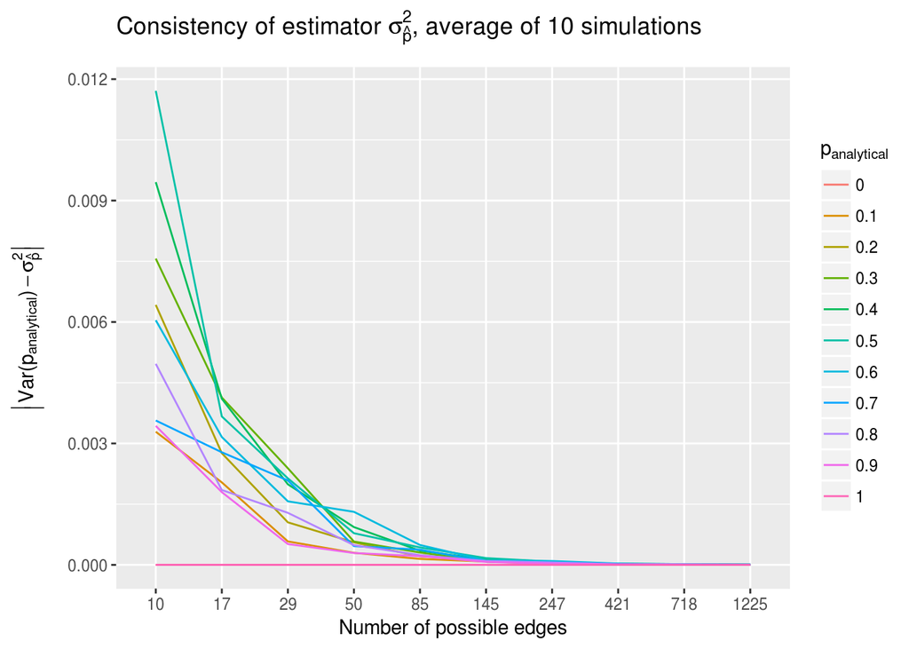

```r
ggplot(results, aes(x = n, y = var, group=p, color=p)) +
  geom_line() +
  ggtitle(TeX('Consistency of estimator $\\sigma^2_{\\hat{p}}$, average of 10 simulations')) +
  xlab("Number of possible edges") +
  ylab(TeX('$\\left|Var(p_{analytical}) - \\sigma^2_{\\hat{p}}\\right|$')) +
  scale_color_discrete(name=TeX("$p_{analytical}$"))
```

As we can see, as our number of possible edges increases, our estimators for $\mu$ and $\sigma^2$ converge, indicating we have consistent estimators.

### Simulated Trials

- Simulate $n$ edges from a binomial distribution given $ne, p + \epsilon$, the alternative samples.
- Simulate $n$ edges from a binomial distribution given $ne, p - \epsilon$, the null samples.
- Compute the empirical distribution for $\hat{p}$ for the alternative and null samples, respectively by repeating the above procedure $ns$ times.
- derive the power from the respective empirical distribution of $\hat{p}$ as the fraction of test statistics more extreme than the critical test statistic.
- compute the difference between the average simulated test statistic and the analytical test statistic.

```r
p = 0.5
diff = seq(0,  0.1, length=21)
ns = round(10^seq(1, log10(1225), length=10))
ndat = length(ns)*length(diff)
empty_ar = array(NaN, dim=c(ndat))
dat = data.frame(ns = empty_ar, diff=empty_ar, pow=empty_ar, tdiff=empty_ar)
counter = 1
for (j in 1:length(ns)) {
  n = ns[j]
  for (i in 1:length(diff)) {
    in.p = p + diff[i]/2
    out.p = p - diff[i]/2
    # under the model, assume the p_in is the mean within group, and p_out is the mean outside of group
    # compute the standard deviation according to the model
    means = c(in.p, out.p)
    result = t.power(means, ne=n)
    dat[counter,] = c(ns=n, diff=diff[i], pow=result$power, tdiff=result$diff)
    counter = counter + 1
  }
}
```

First, we look at power as a function of the number of edges in our simulation, as we vary the difference between the within community and outside community probabilities:

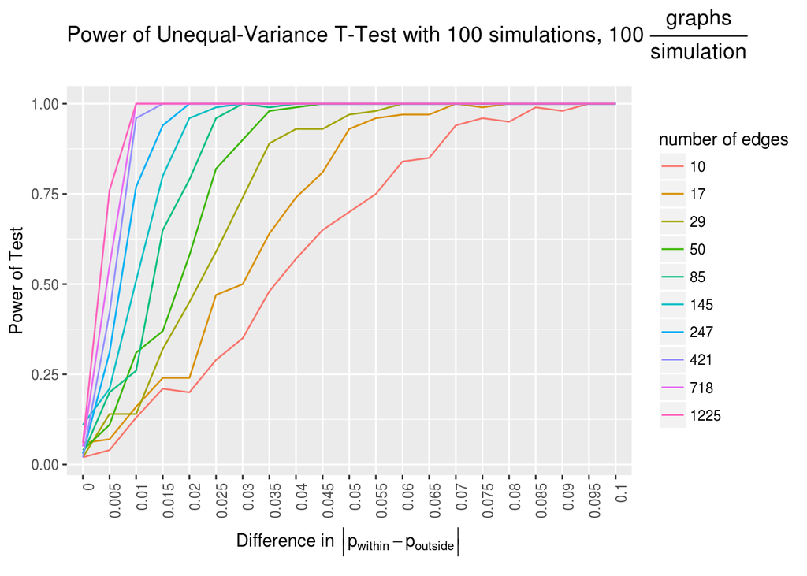

```r
dat$ns = factor(dat$ns)
dat$diff = factor(dat$diff)
thresh = data.frame(diff=diff, sig=.05)
thresh$diff = factor(thresh$diff)
ggplot(dat,  aes(x = diff, y = pow, group=ns, color=ns)) +
  geom_line() +
  ggtitle(TeX('Power of Unequal-Variance T-Test with 100 simulations, 100 $\\frac{graphs}{simulation}$')) +
  xlab(TeX('Difference in $\\left|p_{within} - p_{outside}\\right|$')) +
  ylab('Power of Test') +
  scale_color_discrete(name="number of edges") +
  theme(axis.text.x = element_text(angle = 90, hjust = 1))
```

And we also look at how the analytical test-statistic computed from our trials compares to the empirical test-statistics estimated from our simulation procedure:

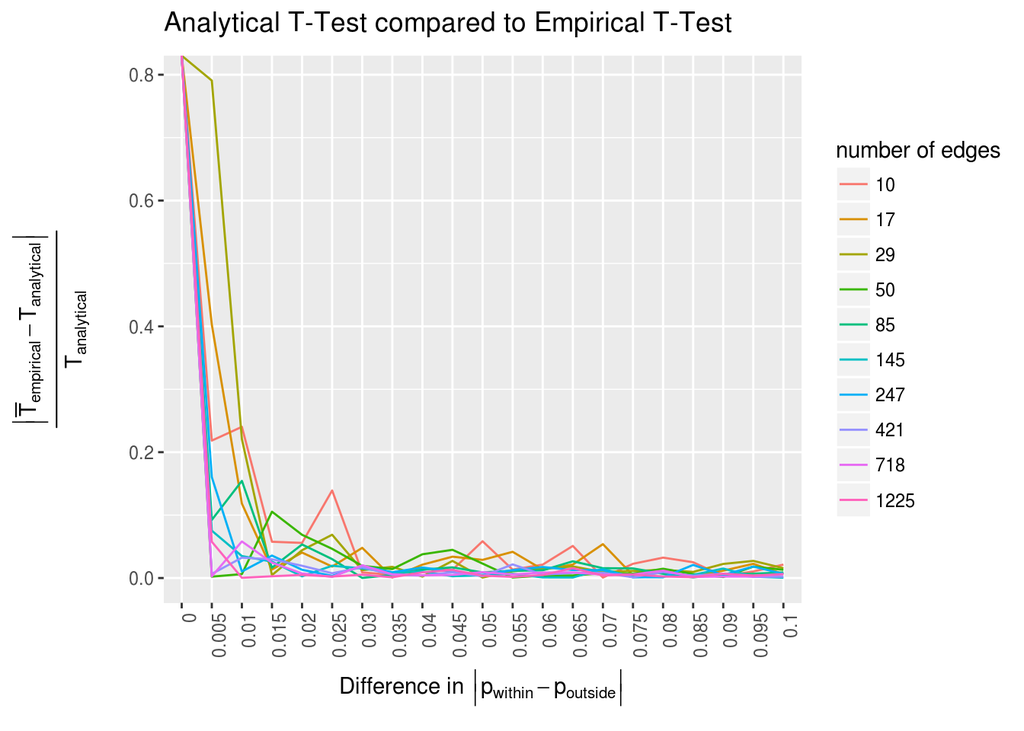

```r
ggplot(dat, aes(x = diff, y = tdiff, group=ns, color=ns)) +
  geom_line() +
  ggtitle(TeX('Analytical T-Test compared to Empirical T-Test')) +
  xlab(TeX('Difference in $\\left|p_{within} - p_{outside}\\right|$')) +
  ylab(TeX('$\\frac{\\left|\\bar{T}_{empirical} - T_{analytical}\\right|}{T_{analytical}}')) +
  scale_color_discrete(name="number of edges") +
  theme(axis.text.x = element_text(angle = 90, hjust = 1))
```

# Real Data Experiments

## Raw Data

For the data, we compute the weighted mean functional (rank of each edge) and diffusion (number of fibers). For the functional connectome, we threshold such that the largest 50% of edges are set to connected, and the smallest 50% set to disconnected. For the diffusion (which are natively sparse) we just threshold edges that are present to connected, and edges that are not present to disconnected (threshold about 0).

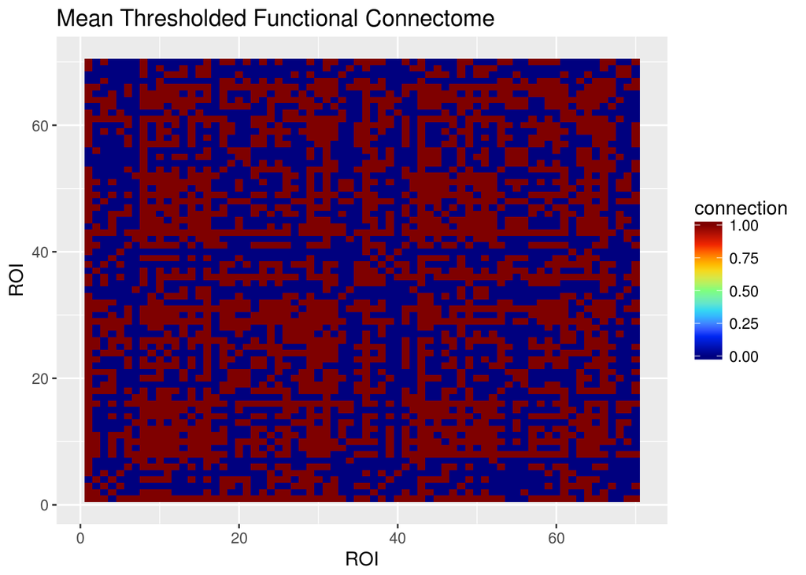

```r
basepath = '/data/connectome_stats/'
fmri_gr = read_graph(file.path(basepath, 'fmrimean_1709.edgelist'), format="ncol")
fmri_mean = get.adjacency(fmri_gr, type="both", sparse=FALSE, attr='weight')
dwi_gr = read_graph(file.path(basepath, 'dwimean_2861.edgelist'), format="ncol")
dwi_mean = get.adjacency(dwi_gr, type="both", sparse=FALSE, attr='weight')

fmri_thresh = thresh_matrix(fmri_mean)
dwi_thresh = thresh_matrix(dwi_mean, thresh=0)

fmriu.plot.plot_graph(fmri_thresh, include_diag = TRUE, title = "Mean Thresholded Functional Connectome", legend.name = "connection")
```

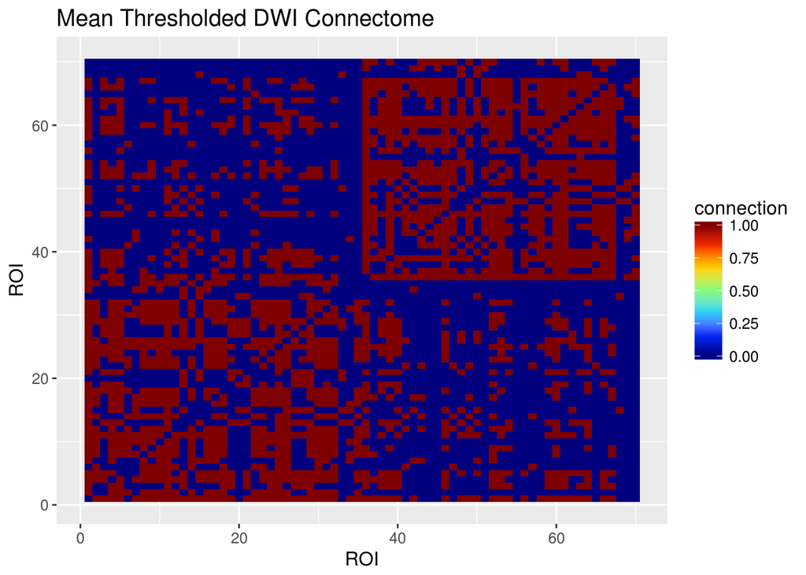

```r
fmriu.plot.plot_graph(dwi_thresh, include_diag = TRUE, title = "Mean Thresholded DWI Connectome", legend.name = "connection")
```

## Blocked Data

here, we will compute the probability of an edge existing in each of 4 quadrants (2 ipsilateral quadrants; 2 contralateral quadrants):

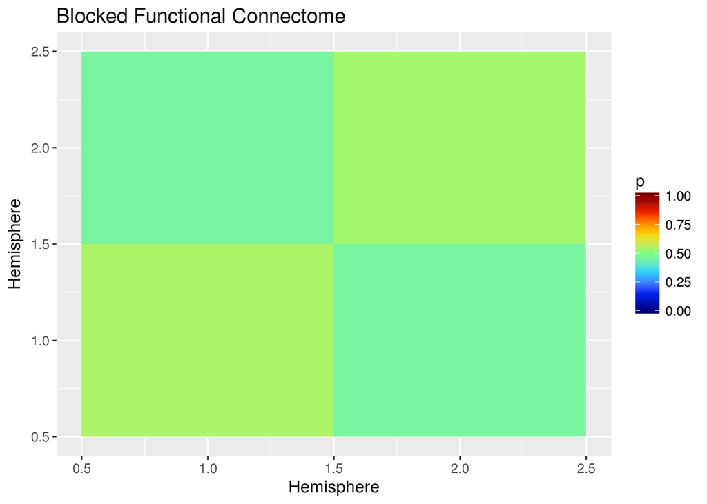

```r
group1 = 1:35
group2 = 36:70
groups = list(group1, group2)
fmri_block = block_data(fmri_thresh, groups)
dwi_block = block_data(dwi_thresh, groups)

fmriu.plot.plot_graph(fmri_block, title = "Blocked Functional Connectome", xlabel = "Hemisphere",
                      ylabel="Hemisphere", include_diag = TRUE, legend.name = "p")
```

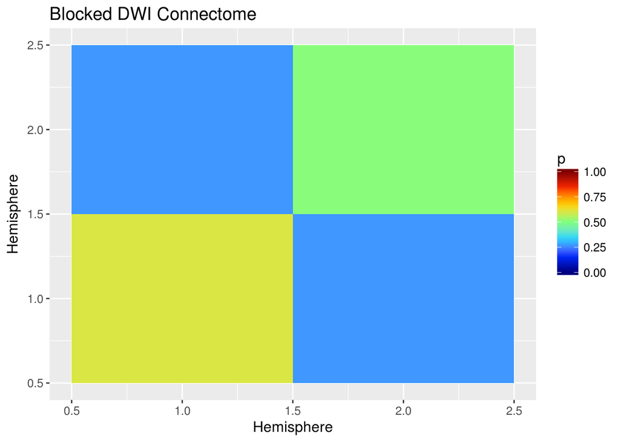

```r
fmriu.plot.plot_graph(dwi_block, title = "Blocked DWI Connectome", xlabel = "Hemisphere",
                      ylabel="Hemisphere", include_diag = TRUE, legend.name = "p")
```

## Difference in Ipsilateral vs. Contralateral Connectivity

### Per-Connectome

Here, we take each functional and diffusion connectome individually, and compute the parameters of our block model for each connectome. We collect all of the ipsi-lateral probabilities as our first sample, and the contra-lateral probabilities as our second sample:

#### Diffusion

```r
dsets = c('BNU1', 'BNU3', 'HNU1', 'KKI2009', 'NKI1', 'NKIENH', 'MRN1313', 'Templeton114', 'Templeton255', 'SWU4')
atlas = 'desikan'
basepath = '/data/dwi/edgelists'

graphobj = fmriu.io.collection.open_graphs(basepath = basepath, atlases = atlas, datasets = dsets, gname = 'ndmg_0-0-48/graphs', fmt='edgelist', rtype = 'array')
```

```
## [1] "opening graphs for BNU1 dataset and desikan parcellation atlas..."
## [1] "opening graphs for BNU3 dataset and desikan parcellation atlas..."
## [1] "opening graphs for HNU1 dataset and desikan parcellation atlas..."
## [1] "opening graphs for KKI2009 dataset and desikan parcellation atlas..."
## [1] "opening graphs for NKI1 dataset and desikan parcellation atlas..."
## [1] "opening graphs for NKIENH dataset and desikan parcellation atlas..."
## [1] "opening graphs for MRN1313 dataset and desikan parcellation atlas..."
## [1] "opening graphs for Templeton114 dataset and desikan parcellation atlas..."
## [1] "opening graphs for Templeton255 dataset and desikan parcellation atlas..."
## [1] "opening graphs for SWU4 dataset and desikan parcellation atlas..."
```

```r
graphs = graphobj$graphs
datasets = graphobj$dataset
```

##### Comparing Distributions of ipsi-lateral and contra-lateral $\hat{p}$ (one p-value total)

```r
ips.phat = array(NaN, dim=c(dim(graphs)[1]))
contr.phat = array(NaN, dim=c(dim(graphs)[1]))
per.p = array(NaN, dim=c(dim(graphs)[1]))
for (i in 1:dim(graphs)[1]) {
  gr = thresh_matrix(graphs[i,,])
  ips = c(gr[group1, group1], gr[group2, group2])
  contr = c(gr[group1, group2], gr[group2, group1])
  ips.phat[i] = mean(ips)
  contr.phat[i] = mean(contr)
  per.p[i] = ana.welch_ttest(ips.phat[i], contr.phat[i], length(ips), length(contr), ns1=1, ns2=1, df = 1)$p
}
```

We might want to visualize the distribution of $\delta = |\hat{p}_{contra} - \hat{p}_{ipsi}|$ under the analytical model and compare to our empirical model:

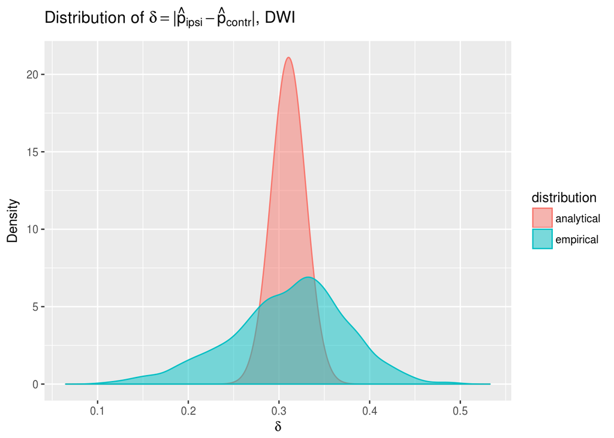

```r
ne = 1225
diff.distr.emp.mod = density(as.numeric(ips.phat - contr.phat))

# variances sum
diff.distr.ana = dnorm(diff.distr.emp.mod$x, mean=mean(abs(ips.phat - contr.phat)), sd=sqrt(model.var(mean(ips.phat), ne) + model.var(mean(contr.phat), ne)))

n_diff = length(diff.distr.emp.mod$x)
diff.dat = data.frame(x = c(diff.distr.emp.mod$x, diff.distr.emp.mod$x), y = c(diff.distr.emp.mod$y, diff.distr.ana),
                      distribution=c(rep("empirical", n_diff), rep("analytical", n_diff)))
diff.dat$distribution = factor(diff.dat$distribution)

ggplot(dat=diff.dat, aes(x=x, y=y, ymax=y, fill=distribution, color=distribution, group=distribution)) +
  geom_ribbon(ymin=0, alpha=0.5) +
  ylab('Density') +
  xlab(TeX('$\\delta$')) +
  ggtitle(TeX('Distribution of $\\delta = |\\hat{p}_{ipsi} - \\hat{p}_{contr}|$, DWI'))
```

which clearly shows a strong difference in the mean contra-laterally compared to ipsi-laterally, as our $\delta$ is generally quite high. Performing a paired t-test between the ipsi-lateral and contra-lateral $\hat{p}$, we find:

```r
t.test(ips.phat, contr.phat, alternative="greater", var.equal=FALSE, paired=TRUE)
```

```
##
##  Paired t-test
##
## data:  ips.phat and contr.phat
## t = 261.66, df = 2857, p-value < 2.2e-16
## alternative hypothesis: true difference in means is greater than 0
## 95 percent confidence interval:
##  0.3086114       Inf
## sample estimates:
## mean of the differences
##               0.3105643
```

which as we can see, indicates a significant difference in ipsi-lateral connectivity compared to contra-lateral connectivity with $p < 2.2\times 10^{-16}$. However, in this case, we note that the model is not very representative of the actual data observed. This is likely due to the fact that much of the data (50%) is acquired from 2 of the sites, so there likely are strong batch-effects present in the $\hat{p}$.

##### Computing p-value per-subject and looking at distribution of p-values (one p-value per-graph)

Below, we look at the distribution of our $p-$values wehre we estimate one p-value per graph:

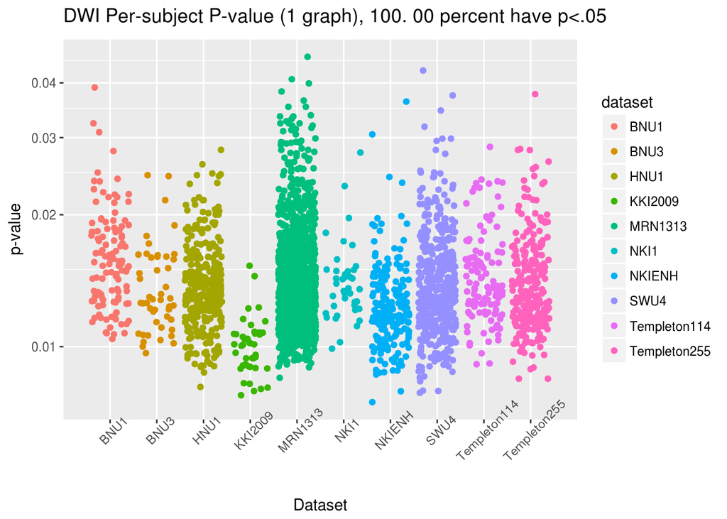

```r
p.dat = data.frame(p=per.p, dataset = datasets)
p.dat$dataset = factor(p.dat$dataset)
ggplot(data=p.dat, aes(x=dataset, y=p, color=dataset, group=dataset)) +
  geom_jitter() +
  coord_trans(y = "log10") +
  ggtitle(TeX(sprintf('DWI Per-subject P-value (1 graph), %.2f percent have $p < .05$', 100*sum(per.p < .05)/length(per.p)))) +
  xlab('Dataset') +
  ylab('p-value') +
  theme(axis.text.x = element_text(angle=45))
```

As we can see, with just $1$ graph, we still see that ipsi-lateral connectivity exceeds contra-lateral connectivity with $p < .05$ for all of the individual graphs.

#### Functional

```r
dsets = c('BNU1', 'BNU2', 'BNU3', 'HNU1', 'IBATRT', 'IPCAS1', 'IPCAS2', 'IPCAS5', 'IPCAS6', 'IPCAS8', 'MRN1', 'NYU1', 'SWU1', 'SWU2', 'SWU3', 'SWU4', 'UWM', 'XHCUMS')
atlas = 'desikan-2mm'
basepath = '/data/fmri_edgelists'

graphobj = fmriu.io.collection.open_graphs(basepath = basepath, atlases = atlas, datasets=dsets, fmt='edgelist', rtype = 'array')
```

```
## [1] "opening graphs for BNU1 dataset and desikan-2mm parcellation atlas..."
## [1] "opening graphs for BNU2 dataset and desikan-2mm parcellation atlas..."
## [1] "opening graphs for BNU3 dataset and desikan-2mm parcellation atlas..."
## [1] "opening graphs for HNU1 dataset and desikan-2mm parcellation atlas..."
## [1] "opening graphs for IBATRT dataset and desikan-2mm parcellation atlas..."
## [1] "opening graphs for IPCAS1 dataset and desikan-2mm parcellation atlas..."
## [1] "opening graphs for IPCAS2 dataset and desikan-2mm parcellation atlas..."
## [1] "opening graphs for IPCAS5 dataset and desikan-2mm parcellation atlas..."
## [1] "opening graphs for IPCAS6 dataset and desikan-2mm parcellation atlas..."
## [1] "opening graphs for IPCAS8 dataset and desikan-2mm parcellation atlas..."
## [1] "opening graphs for MRN1 dataset and desikan-2mm parcellation atlas..."
## [1] "opening graphs for NYU1 dataset and desikan-2mm parcellation atlas..."
## [1] "opening graphs for SWU1 dataset and desikan-2mm parcellation atlas..."
## [1] "opening graphs for SWU2 dataset and desikan-2mm parcellation atlas..."
## [1] "opening graphs for SWU3 dataset and desikan-2mm parcellation atlas..."
## [1] "opening graphs for SWU4 dataset and desikan-2mm parcellation atlas..."
## [1] "opening graphs for UWM dataset and desikan-2mm parcellation atlas..."
## [1] "opening graphs for XHCUMS dataset and desikan-2mm parcellation atlas..."
```

```r
graphs = graphobj$graphs
datasets = graphobj$dataset
```

```r
ips.phat = array(NaN, dim=c(dim(graphs)[1]))
contr.phat = array(NaN, dim=c(dim(graphs)[1]))
per.p = array(NaN, dim=c(dim(graphs)[1]))
for (i in 1:dim(graphs)[1]) {
  gr = thresh_matrix(graphs[i,,])
  ips = c(gr[group1, group1], gr[group2, group2])
  contr = c(gr[group1, group2], gr[group2, group1])
  ips.phat[i] = mean(ips)
  contr.phat[i] = mean(contr)
  per.p = ana.welch_ttest(ips.phat[i], contr.phat[i], length(ips), length(contr), ns1=1, ns2=1, df = 1)
}
```

##### Comparing Distributions of ipsi-lateral and contra-lateral $\hat{p}$ (one p-value total)

We might want to visualize the distribution of $\hat{p}_{contra}$ and $\hat{p}_{ipsi}$ under the analytical model and compare to our empirical model:

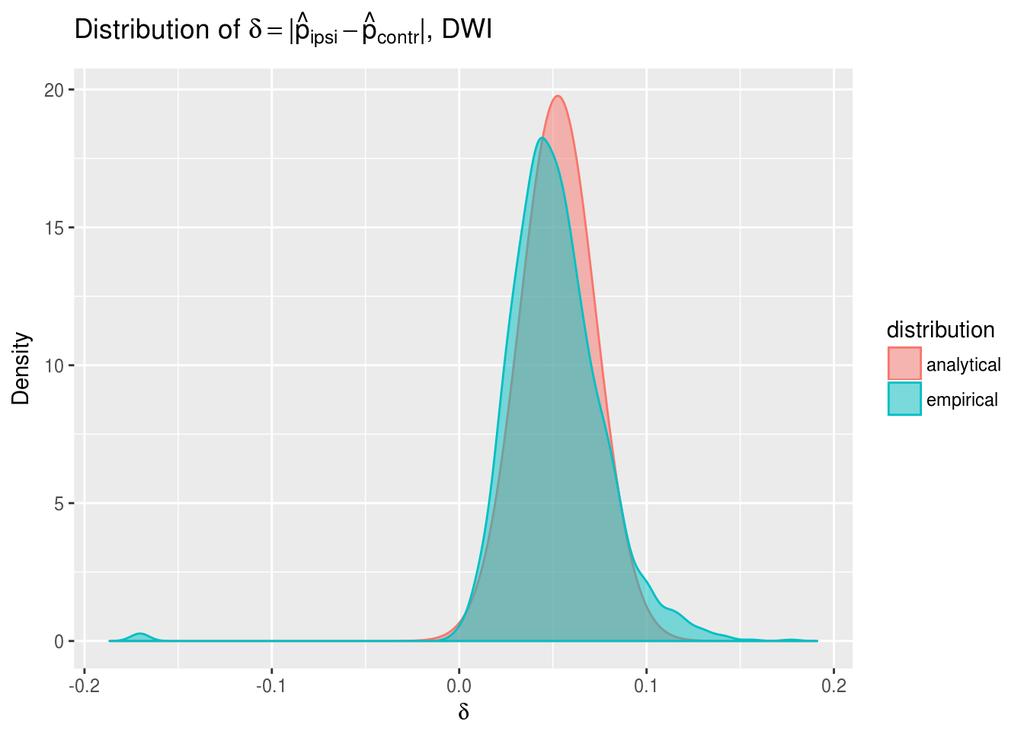

```r
ne = 1225
diff.distr.emp.mod = density(as.numeric(ips.phat - contr.phat))

# variances sum
diff.distr.ana = dnorm(diff.distr.emp.mod$x, mean=mean(abs(ips.phat - contr.phat)), sd=sqrt(model.var(mean(ips.phat), ne) + model.var(mean(contr.phat), ne)))

n_diff = length(diff.distr.emp.mod$x)
diff.dat = data.frame(x = c(diff.distr.emp.mod$x, diff.distr.emp.mod$x), y = c(diff.distr.emp.mod$y, diff.distr.ana),
                      distribution=c(rep("empirical", n_diff), rep("analytical", n_diff)))
diff.dat$distribution = factor(diff.dat$distribution)

ggplot(dat=diff.dat, aes(x=x, y=y, ymax=y, fill=distribution, color=distribution, group=distribution)) +
  geom_ribbon(ymin=0, alpha=0.5) +
  ylab('Density') +
  xlab(TeX('$\\delta$')) +
  ggtitle(TeX('Distribution of $\\delta = |\\hat{p}_{ipsi} - \\hat{p}_{contr}|$, DWI'))
```

which clearly shows a strong difference in the means contra-laterally compared to ipsi-laterally. Performing a t-test, we find:

```r
t.test(ips.phat, contr.phat, alternative="greater", var.equal=FALSE, paired=TRUE)
```

```
##
##  Paired t-test
##
## data:  ips.phat and contr.phat
## t = 81.738, df = 1796, p-value < 2.2e-16
## alternative hypothesis: true difference in means is greater than 0
## 95 percent confidence interval:
##  0.05045877        Inf
## sample estimates:
## mean of the differences
##              0.05149558
```

similar to the diffusion connectomes, the functional connectomes again exhibit a difference in intr-lateral vs. contra-lateral connectivity that is significant with $p < 2.2\times 10^{-16}$. The fit here is much better, likely due to the fact that the largest site accounts for only 20% of the total data, and the second largest site just 10%, so fewer batch effects will be apparent compared to the diffusion data.

##### Computing p-value per-subject and looking at distribution of p-values (one p-value per-graph)

Below, we look at the distribution of our $p-$values wehre we estimate one p-value per graph:

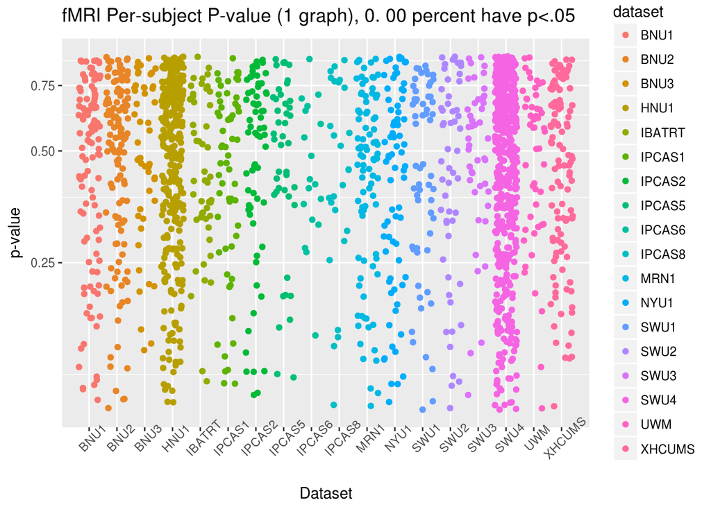

```r
p.dat = data.frame(p=per.p, dataset = datasets)
p.dat$dataset = factor(p.dat$dataset)
ggplot(data=p.dat, aes(x=dataset, y=p, color=dataset, group=dataset)) +
  geom_jitter() +
  ggtitle(TeX(sprintf('fMRI Per-subject P-value (1 graph), %.2f percent have $p < .05$', 100*sum(per.p < .05)/length(per.p)))) +
  coord_trans(y = "log10") +
  xlab('Dataset') +
  ylab('p-value') +
  theme(axis.text.x = element_text(angle=45))
```

As we can see, with just $1$ graph, we do not have nearly the confidence that the ipsi-lateral connectivity exceeds the contra-lateral connectivity that we did with the diffusion graphs.

### Aggregated

Here, we aggregate all of the edge weights ipsilaterally and contralaterally, along with the number of edges this information is aggregated over for each connection type. We feed this into a simple t-test with the appropriate assumptions (unequal variance, goal is to test for ipsilateral connectivity exceeding contralateral connectivity):

### Functional

```r
fips = c(fmri_thresh[group1, group1], fmri_thresh[group2, group2])
fcontr = c(fmri_thresh[group1, group2], fmri_thresh[group2, group1])
ips.p = mean(fips)
contr.p = mean(fcontr)

ana.welch_ttest(ips.p, contr.p, length(fips), length(fcontr), ns1=1, ns2=1, df = 1)
```

```
## $t
## [1] 5.44497
##
## $p
## [1] 0.05781516
##
## $df
## [1] 1
```

### Diffusion

```r
dips = c(dwi_thresh[group1, group1], dwi_thresh[group2, group2])
dcontr = c(dwi_thresh[group1, group2], dwi_thresh[group2, group1])

ips.p = mean(dips)
contr.p = mean(dcontr)

ana.welch_ttest(ips.p, contr.p, length(dips), length(dcontr), ns1=1, ns2=1, df = 1)
```

```
## $t
## [1] 21.29186
##
## $p
## [1] 0.01493886
##
## $df
## [1] 1
```